# iDEP: Investigating Differentially Expressed Genes

## If this site has contributed to your work, please cite our article:

Ge, S.X., Son, E.W. & Yao, R. iDEP: an integrated web application for differential expression and pathway analysis of RNA-Seq data. BMC Bioinformatics 19, 534 (2018). https://doi.org/10.1186/s12859-018-2486-6

## Summary

Read Counts data were analyzed using iDEP v2.4.4. The data was first filtered to remove reads below 0.5 CPM in at least 1 sample. Then the data was transformed with EdgeR using a pseudocount of 4. Missing values were imputed using geneMedian.

After mapping, there are 32833 unique genes in 158 samples. Of the 24127 genes passed filter, 24127 were converted to Ensembl/STRING gene IDs in our database. The remaining 0 genes were kept in the data using original IDs.

Differential expression analysis was performed using DESeq2 with an FDR cutoff of 0.1 and a minimum fold-change threshold of 2. Standard Wald test was used and independent filtering was enabled.

## Selected Comparison: Time_After_Treatment_min45-Time_After_Treatment_min0

Up-regulated genes: 383

Down-regulated genes: 900

## Top Up-regulated Genes

```r
if (!is.null(params$up_genes_table) && nrow(params$up_genes_table) > 0) {
  kbl(params$up_genes_table, escape = FALSE) %>%
    kable_classic(full_width = FALSE, html_font = "Cambria")
} else {
  print("No up-regulated genes found for this comparison.")
}
```

| Symbol | Ensembl ID | log2 FC | Adj. P-value | Description |
| --- | --- | --- | --- | --- |
| AT2G09785 | AT2G09785 | 16.703 | 2.05e-03 | NcRNA |
| AT1G04163 | AT1G04163 | 13.713 | 9.54e-03 | NcRNA |
| AT1G05767 | AT1G05767 | 11.963 | 1.43e-06 | S-adenosyl-L-methionine-dependent methyltransferases superfamily protein |
| AT1G07500 | AT1G07500 | 10.310 | 7.06e-06 | Uncharacterized protein |
| AT3G51070 | AT3G51070 | 7.136 | 2.42e-03 | S-adenosyl-L-methionine-dependent methyltransferases superfamily protein |
| AT1G05837 | AT1G05837 | 4.379 | 4.32e-02 | NcRNA |
| AT2G39855 | AT2G39855 | 3.776 | 4.15e-03 | Plant/protein |
| HB21 AT2G18550 | AT2G18550 | 3.460 | 1.52e-03 | Homeobox protein 21 |
| WRKY38 | AT5G22570 | 3.376 | 6.95e-03 | WRKY DNA-binding protein 38 |
| AT3G07105 | AT3G07105 | 3.353 | 1.90e-02 | NcRNA |
| AT5G44440 | AT5G44440 | 3.312 | 1.73e-02 | FAD-binding Berberine family protein |
| AT5G06695 | AT5G06695 | 2.989 | 3.57e-02 | NcRNA |
| AT5G44260 | AT5G44260 | 2.713 | 3.92e-03 | Zinc finger C-x8-C-x5-C-x3-H type family protein |
| HSFA6A | AT5G43840 | 2.707 | 5.47e-02 | Heat shock transcription factor A6A |
| AT4G37220 | AT4G37220 | 2.602 | 1.74e-03 | Cold acclimation protein WCOR413 family |
| AT1G18990 | AT1G18990 | 2.598 | 1.44e-03 | Myosin-binding protein, putative (Protein of unknown function, DUF593) |
| AT1G75490 | AT1G75490 | 2.520 | 5.27e-03 | Integrase-type DNA-binding superfamily protein |
| AT4G13160 | AT4G13160 | 2.507 | 1.66e-02 | Zein-binding protein (Protein of unknown function, DUF593) |
| ASN1 | AT3G47340 | 2.436 | 3.41e-02 | Glutamine-dependent asparagine synthase 1 |
| SPL3 | AT2G33810 | 2.425 | 9.19e-02 | Squamosa promoter binding protein-like 3 |
| AT3G43850 | AT3G43850 | 2.416 | 6.74e-02 | Uncharacterized protein |
| P1R3 | AT3G29370 | 2.360 | 1.47e-02 | Uncharacterized protein |
| AT5G63350 | AT5G63350 | 2.358 | 4.15e-03 | Von willebrand factor A domain protein |
| AT4G26288 | AT4G26288 | 2.339 | 1.40e-03 | Uncharacterized protein |
| MGL | AT1G64660 | 2.297 | 3.55e-07 | Methionine gamma-lyase |
| ERF1 | AT3G23240 | 2.290 | 9.13e-02 | Ethylene response factor 1 |
| IAA34 | AT1G15050 | 2.262 | 1.46e-02 | Indole-3-acetic acid inducible 34 |
| AT4G15990 | AT4G15990 | 2.258 | 5.65e-04 | Uncharacterized protein |
| AT1G10980 | AT1G10980 | 2.252 | 2.27e-02 | Lung seven transmembrane receptor family protein |
| WRKY75 | AT5G13080 | 2.226 | 5.85e-03 | WRKY DNA-binding protein 75 |
| AT1G23160 | AT1G23160 | 2.195 | 7.20e-02 | Auxin-responsive GH3 family protein |
| AT1G72060 | AT1G72060 | 2.176 | 4.38e-03 | Serine-type endopeptidase inhibitor |
| ATMG00730 | ATMG00730 | 2.174 | 5.52e-02 |  |
| STP1 | AT1G11260 | 2.170 | 4.08e-05 | Sugar transporter 1 |
| AT2G07734 | AT2G07734 | 2.158 | 2.43e-02 | Alpha-L RNA-binding motif/Ribosomal protein S4 family protein |
| AT1G05397 | AT1G05397 | 2.147 | 2.36e-02 | NcRNA |
| THA1 | AT1G08630 | 2.145 | 4.63e-02 | Threonine aldolase 1 |
| CBSX5 | AT4G27460 | 2.129 | 5.95e-04 | Cystathionine beta-synthase (CBS) family protein |
| ATMG01320 | ATMG01320 | 2.125 | 1.74e-02 |  |
| AT3G24575 | AT3G24575 | 2.122 | 6.78e-02 | Uncharacterized protein |
| AT2G07785 | AT2G07785 | 2.098 | 2.66e-02 | NADH dehydrogenase family protein |
| AT2G15880 | AT2G15880 | 2.083 | 7.00e-03 | Leucine-rich repeat (LRR) family protein |
| AT1G21400 | AT1G21400 | 2.078 | 6.37e-04 | Thiamine diphosphate-binding fold (THDP-binding) superfamily protein |
| AT4G36850 | AT4G36850 | 2.073 | 3.20e-02 | PQ-loop repeat family protein / transmembrane family protein |
| BT1 | AT5G63160 | 2.072 | 7.25e-04 | BTB and TAZ domain protein 1 |
| TIP2;3 | AT5G47450 | 2.062 | 1.00e-04 | Tonoplast intrinsic protein 2 |
| AT4G10500 | AT4G10500 | 2.033 | 5.28e-02 | 2-oxoglutarate (2OG) and Fe(II)-dependent oxygenase superfamily protein |
| ATL8 | AT1G76410 | 2.002 | 3.18e-04 | RING/U-box superfamily protein |
| NAMT1 | AT5G04370 | 2.000 | 7.74e-04 | S-adenosyl-L-methionine-dependent methyltransferases superfamily protein |
| AT4G01335 | AT4G01335 | 1.980 | 4.52e-02 | TATA box-binding protein associated factor RNA polymerase I subunit B-like protein |

## Top Down-regulated Genes

```r
if (!is.null(params$down_genes_table) && nrow(params$down_genes_table) > 0) {
  kbl(params$down_genes_table, escape = FALSE) %>%
    kable_classic(full_width = FALSE, html_font = "Cambria")
} else {
  print("No down-regulated genes found for this comparison.")
}
```

| Symbol | Ensembl ID | log2 FC | Adj. P-value | Description |
| --- | --- | --- | --- | --- |
| AT5G01645 | AT5G01645 | -47.401 | 6.38e-66 | NcRNA |
| AT1G05562 | AT1G05562 | -22.487 | 4.23e-03 | NcRNA |
| AT5G42825 | AT5G42825 | -18.709 | 8.41e-11 | Uncharacterized protein |
| ACT12 | AT3G46520 | -14.708 | 7.86e-07 | Actin-12 |
| GMD1 | AT5G66280 | -11.588 | 1.47e-08 | GDP-D-mannose 4,6-dehydratase 1 |
| AT1G09053 | AT1G09053 | -8.707 | 7.48e-03 | NcRNA |
| AT5G06235 | AT5G06235 | -6.936 | 2.15e-04 | NcRNA |
| AT3G56920 | AT3G56920 | -6.814 | 2.18e-03 | DHHC-type zinc finger family protein |
| AT3G51238 | AT3G51238 | -6.544 | 2.85e-05 | NcRNA |
| AT3G01205 | AT3G01205 | -6.439 | 2.51e-03 | NcRNA |
| AT2G35859 | AT2G35859 | -6.412 | 2.25e-04 | NcRNA |
| ADT6 | AT1G08250 | -5.918 | 7.69e-03 | Arogenate dehydratase 6 |
| AT1G08387 | AT1G08387 | -5.574 | 4.01e-03 | NcRNA |
| NRT2:1 | AT1G08090 | -5.400 | 3.97e-04 | Nitrate transporter 2:1 |
| SWEET14 | AT4G25010 | -5.347 | 1.82e-03 | Nodulin MtN3 family protein |
| ATMG00290 | ATMG00290 | -5.167 | 3.43e-02 |  |
| AT2G41810 | AT2G41810 | -5.057 | 4.97e-03 | Imidazolonepropionase (Protein of unknown function, DUF642) |
| AT2G35640 | AT2G35640 | -4.905 | 4.41e-02 | Homeodomain-like superfamily protein |
| AT1G26390 | AT1G26390 | -4.904 | 5.92e-02 | FAD-binding Berberine family protein |
| CYP71A12 | AT2G30750 | -4.887 | 2.32e-03 | Cytochrome P450 family 71 polypeptide |
| AT1G73325 | AT1G73325 | -4.883 | 3.81e-03 | Kunitz family trypsin and protease inhibitor protein |
| AT1G75300 | AT1G75300 | -4.858 | 1.64e-03 | NmrA-like negative transcriptional regulator family protein |
| AT3G03535 | AT3G03535 | -4.814 | 9.92e-02 | NcRNA |
| AT3G50610 | AT3G50610 | -4.813 | 4.78e-03 | DNA-directed RNA polymerase II subunit RPB1-like protein |
| AT1G68723 | AT1G68723 | -4.809 | 2.04e-02 | Uncharacterized protein |
| LSU2 | AT5G24660 | -4.758 | 6.03e-06 | Response to low sulfur 2 |
| AT2G27420 | AT2G27420 | -4.745 | 2.18e-06 | Cysteine proteinases superfamily protein |
| NRT2.3 | AT5G60780 | -4.727 | 1.09e-04 | Nitrate transporter 2.3 |
| AT1G26240 | AT1G26240 | -4.673 | 3.66e-02 | Proline-rich extensin-like family protein |
| CRK6 | AT4G23140 | -4.492 | 3.32e-03 | Cysteine-rich RLK (RECEPTOR-like protein kinase) 6 |
| AT3G44450 | AT3G44450 | -4.475 | 1.47e-08 | Uncharacterized protein |
| AT4G34550 | AT4G34550 | -4.444 | 3.98e-03 | F-box protein |
| AT1G20750 | AT1G20750 | -4.295 | 2.29e-02 | RAD3-like DNA-binding helicase protein |
| NAC085 | AT5G14490 | -4.148 | 7.64e-03 | NAC domain containing protein 85 |
| SULTR1;3 | AT1G22150 | -4.058 | 1.95e-03 | Sulfate transporter 1 |
| AT5G63087 | AT5G63087 | -4.024 | 1.25e-02 | Plant thionin family protein |
| BGLU28 | AT2G44460 | -3.990 | 2.67e-02 | Beta glucosidase 28 |
| AT1G14550 | AT1G14550 | -3.977 | 4.65e-02 | Peroxidase superfamily protein |
| AT3G46890 | AT3G46890 | -3.974 | 8.56e-04 | Maternal effect embryo arrest protein |
| AT1G76955 | AT1G76955 | -3.953 | 7.65e-03 | Uncharacterized protein |
| ATSDI1 | AT5G48850 | -3.865 | 2.38e-03 | Tetratricopeptide repeat (TPR)-like superfamily protein |
| ELIP1 | AT3G22840 | -3.796 | 2.71e-07 | Chlorophyll A-B binding family protein |
| GDPD6 | AT5G08030 | -3.755 | 1.15e-02 | PLC-like phosphodiesterases superfamily protein |
| AT1G08273 | AT1G08273 | -3.748 | 1.84e-02 | NcRNA |
| AT2G22590 | AT2G22590 | -3.721 | 1.13e-03 | UDP-Glycosyltransferase superfamily protein |
| BBX31 | AT3G21890 | -3.700 | 8.00e-05 | B-box type zinc finger family protein |
| AAE12 | AT1G65890 | -3.660 | 1.83e-03 | Acyl activating enzyme 12 |
| AT5G46140 | AT5G46140 | -3.648 | 1.23e-02 |  |
| AT5G66815 | AT5G66815 | -3.647 | 2.00e-02 | Uncharacterized protein |
| AT4G06810 | AT4G06810 | -3.641 | 8.09e-02 | NcRNA |

## DEG Heatmap

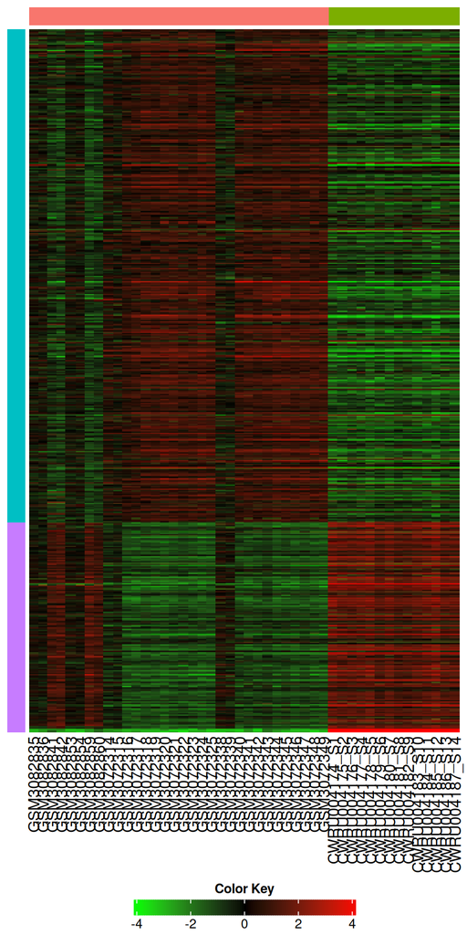

```r
if (!is.null(params$heat_data) && !is.null(params$heat_bar)) {
  heat_colors <- unlist(strsplit(params$heatmap_color_select, "-"))

  deg_heatmap(
    df = params$heat_data,
    bar = params$heat_bar,
    heatmap_color_select = heat_colors,
    cluster_rows = FALSE
  )
}
```

## Volcano Plot

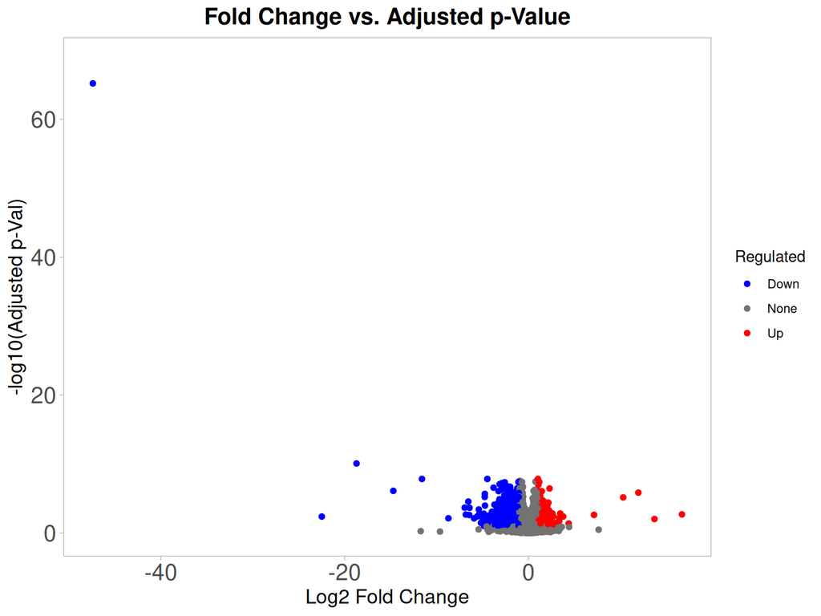

```r
if (!is.null(params$vol_data) && !is.null(params$vol_data$data)) {
  p <- plot_volcano(
    data = params$vol_data$data,
    plot_colors = params$plot_colors,
    anotate_genes = params$gene_labels_volcano
  )
  p <- refine_ggplot2(
    p = p,
    gridline = params$plot_grid_lines,
    ggplot2_theme = params$ggplot2_theme
  )
  print(p)
}
```

## MA Plot

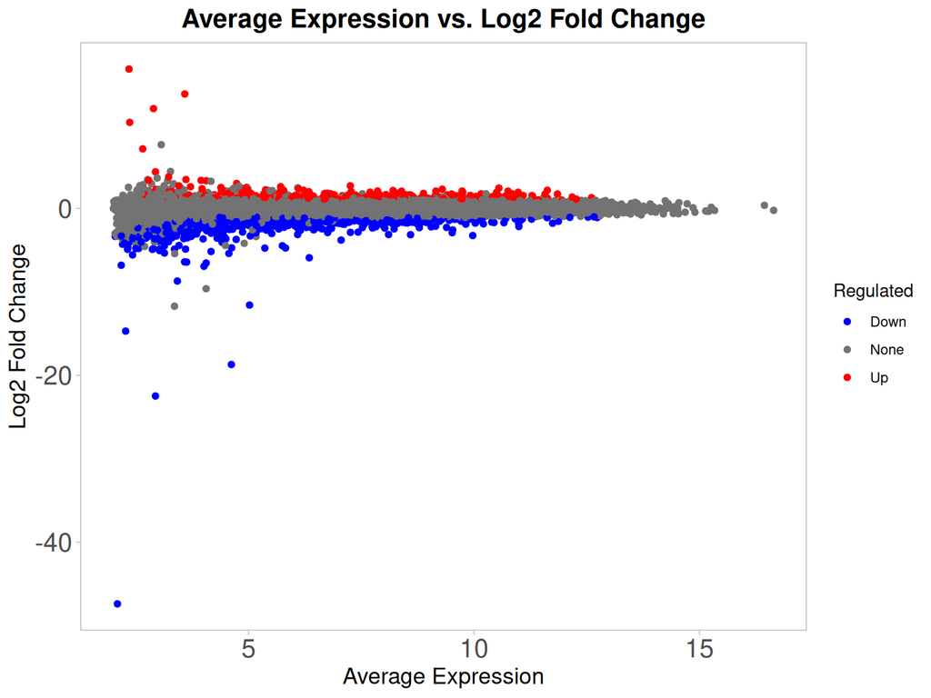

```r
if (!is.null(params$vol_data) && !is.null(params$vol_data$data)) {
  p <- plot_ma(
    data = params$vol_data$data,
    plot_colors = params$plot_colors,
    anotate_genes = params$gene_labels_ma
  )
  p <- refine_ggplot2(
    p = p,
    gridline = params$plot_grid_lines,
    ggplot2_theme = params$ggplot2_theme
  )
  print(p)
}
```

## Scatter Plot

[figure not shown]

```r
if (!is.null(params$top_genes) && !is.null(params$comparisons)) {
  p <- plot_deg_scatter(
    select_contrast = params$select_contrast,
    comparisons = params$comparisons,
    top_genes = params$top_genes,
    limma_p_val = params$limma_p_val,
    limma_fc = params$limma_fc,
    contrast_samples = params$contrast_samples,
    processed_data = params$processed_data,
    sample_info = params$sample_info,
    plot_colors = params$plot_colors,
    all_gene_names = params$all_gene_names,
    select_gene_id = params$select_gene_id,
    anotate_genes = params$gene_labels_scatter
  )
  p <- refine_ggplot2(
    p = p,
    gridline = params$plot_grid_lines,
    ggplot2_theme = params$ggplot2_theme
  )
  print(p)
}
```

Generated using iDEP v2.4.4 (https://bioinformatics.sdstate.edu/idep). 2026-06-14 21:26:16 UTC. Accuracy not guaranteed.